# Benchmarking exFINDER using human skin data

Changhan He

02 三月, 2023

This vignette outlines the steps of benchmarking exFINDER. We use subsets of cells in a dataset to infer ligand-receptor communication from the rest cells in the dataset. Specifically, we evaluate its performance on using the published human skin scRNA-seq dataset (He, Helen, et al. Journal of Allergy and Clinical Immunology, 2020).

## Load the required libraries

```r
library(exFINDER)
library(Seurat)
library(ggplot2)
library(patchwork)
library(RColorBrewer)
library(dplyr)
library(pheatmap)
library(ggraph)

# the following packages are for CellChat analysis
library(CellChat)
library(patchwork)
library(forcats)
library(base)
library(extrafont)
options(stringsAsFactors = FALSE)
```

## Part I: Load and process human skin dataset

The processed data (Seurat object) can be downloaded from: https://figshare.com/s/e5b9f3700ee967a26523

```r
# the dataset can be downloaded using the following link:
load(url("https://ndownloader.figshare.com/files/25950872"))

# change the labels to portable format
data_humanSkin$meta$labels <- fct_collapse(data_humanSkin$meta$labels, "APOE+FIB"="APOE+ FIB",
                                           "CD40LG+TC"="CD40LG+ TC",
                                           "COL11A1+FIB"="COL11A1+ FIB",
                                           "FBN1+FIB"="FBN1+ FIB",
                                           "Inflam.DC"="Inflam. DC",
                                           "Inflam.FIB"="Inflam. FIB",
                                           "Inflam.TC"="Inflam. TC")

# creat Seurat object
Data_human <- CreateSeuratObject(data_humanSkin$data, project = "SeuratProject", assay = "RNA",
  min.cells = 0, min.features = 0, names.field = 1,
  names.delim = "_", meta.data = data_humanSkin$meta)

# Seperate two conditions (here we only use one condition)
Data_human <- Data_human[, Data_human@meta.data$condition %in% c("LS")]

# Normalize the data
Data_human <- NormalizeData(Data_human)

# Scale the data
all.genes <- rownames(Data_human)
Data_human <- ScaleData(Data_human, features = all.genes)
```

## Part II: Discover marker genes of each cell population group

We use the processed data (Seurat object) to discover marker genes of all cell groups.

```r
Data1 <- Data_human
Data1@meta.data$Type <- as.factor(Data1@meta.data$labels)
Data1 = UpdateSeuratObject(object = Data1)
```

```
#> Validating object structure
#> Updating object slots
#> Ensuring keys are in the proper structure
#> Ensuring feature names don't have underscores or pipes
#> Object representation is consistent with the most current Seurat version
```

All marker genes are analyzed by running the following chunck and saved in folder “../markers/He2020_Human_marker”.

```r
# Type <- levels(Data1@meta.data$Type)
# n <- length(Type)
# Data1.marker <- c()
#
# for (i in 1:n) {
#   cluster.markers <- FindMarkers(Data1,
#                                  ident.1 = Type[i] ,
#                                  group.by = "Type",
#                                  only.pos = TRUE,
#                                  min.pct = 0.25,
#                                  logfc.threshold = 0.25)
#
#   cluster.markers %>%
#     slice_max(order_by = -p_val)
#   cluster.markers <- cluster.markers[1:100,]
#
#   Data1.marker <- c(Data1.marker, rownames(cluster.markers[1:10, ]))
#
#   write.csv(x = cluster.markers , file = paste("../markers/He2020_Human_marker/He2020_Human_markers_",Type[i],".csv",sep=""))
# }
```

Once all marker genes are saved, we can visualize the top10 markers of each group by running the following chunck.

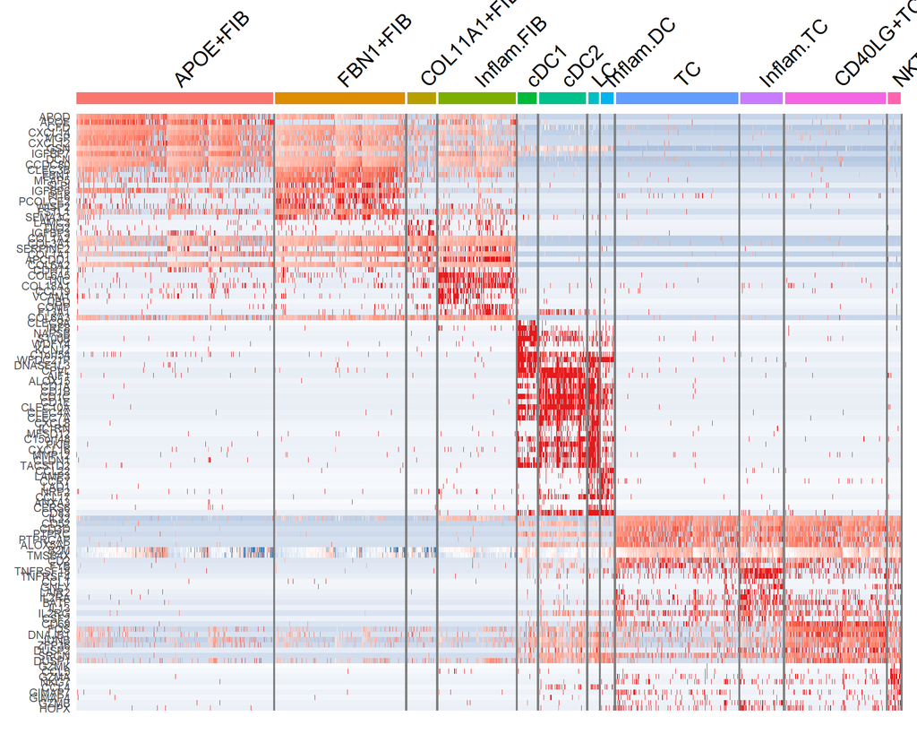

```r
# if all marker genes are saved, we can directly load and visualize
Type <- levels(Data1@meta.data$Type)
n <- length(Type)
Data1@active.ident <- Data1@meta.data$Type
Data1.marker <- c()

for (i in 1:n) {
  cluster.markers <- read.csv(file = paste("../markers/He2020_Human_marker/He2020_Human_markers_",Type[i],".csv",sep=""))
  cluster.markers <- cluster.markers$X[1:10]
  Data1.marker <- c(Data1.marker, cluster.markers)
}

DoHeatmap(Data1, features = Data1.marker) + NoLegend() +
  scale_fill_gradientn(colors = c("#377EB8", "white", "#E41A1C"))
```

# Part III: Infer ligands using CellChat

Here, we select four cell groups from the original dataset: two subpopulations of dendritic cells (cDC2 and LC) and two subpopulations of fibroblasts cells (FBN1+ FIB and APOE+ FIB). We then perform CellChat analysis to infer cell-cell communication between these cell groups and exported the corresponding ligands in the following way:

(1). CellChat analysis on the data of all four cell groups: cDC2, LC, FBN1+ FIB, and APOE+ FIB; (2). CellChat analysis on four datasets, each containing three of the above four cell groups.

Then by comparing the inferred ligands, we can obtain the CellChat-inferred, cell group-specific ligands, for example: ligands targeting FBN1+ FIB cells but only expressed in the APOE+ FIB cells.

We followed the official workflow of CellChat analysis.

## Generate CellChat objects

Setup inputs (original dataset with corrected labels)

```r
data = data_humanSkin$data # normalized data matrix
meta = data_humanSkin$meta # a dataframe with rownames containing cell mata data
```

Generate 5 CellChat objects for the analysis.

```r
# no "LC" cells
cell.use1 = rownames(meta)[meta$condition == "LS" & meta$labels %in% c("cDC2", "FBN1+FIB", "APOE+FIB")]
# no "cDC2" cells
cell.use2 = rownames(meta)[meta$condition == "LS" & meta$labels %in% c("LC", "FBN1+FIB", "APOE+FIB")]
# no "FBN1+ FIB" cells
cell.use3 = rownames(meta)[meta$condition == "LS" & meta$labels %in% c("LC", "cDC2", "APOE+FIB")]
# no "APOE+ FIB" cells
cell.use4 = rownames(meta)[meta$condition == "LS" & meta$labels %in% c("LC", "cDC2", "FBN1+FIB")]
# All four cell groups
cell.use5 = rownames(meta)[meta$condition == "LS" & meta$labels %in% c("LC", "cDC2", "FBN1+FIB", "APOE+FIB")]

barcode <- mget(paste0('cell.use', 1:5))
All.cellchat <- list()

for (i in 1:5) {
  data.input = data[, barcode[[i]]]
  meta.input = meta[barcode[[i]], ]

  newlabels <- fct_drop(meta.input$labels)
  meta.input$newlabels <- newlabels

  cellchat <- createCellChat(object = data.input, meta = meta.input, group.by = "newlabels")
  All.cellchat[[i]] <- cellchat
  # saveRDS(cellchat, file = paste("path/cellchat",i,".rds",sep=""))
}
```

```
#> Create a CellChat object from a data matrix
#> Set cell identities for the new CellChat object
#> The cell groups used for CellChat analysis are  APOE+FIB FBN1+FIB cDC2
#> Create a CellChat object from a data matrix
#> Set cell identities for the new CellChat object
#> The cell groups used for CellChat analysis are  APOE+FIB FBN1+FIB LC
#> Create a CellChat object from a data matrix
#> Set cell identities for the new CellChat object
#> The cell groups used for CellChat analysis are  APOE+FIB cDC2 LC
#> Create a CellChat object from a data matrix
#> Set cell identities for the new CellChat object
#> The cell groups used for CellChat analysis are  FBN1+FIB cDC2 LC
#> Create a CellChat object from a data matrix
#> Set cell identities for the new CellChat object
#> The cell groups used for CellChat analysis are  APOE+FIB FBN1+FIB cDC2 LC
```

```r
names(All.cellchat)<-c('cellchat1', 'cellchat2', 'cellchat3', 'cellchat4', 'cellchat5')
```

## CellChat analysis

For detialed explaination, please check CellChat’s webpage: http://www.cellchat.org/ (or https://htmlpreview.github.io/?https://github.com/sqjin/CellChat/blob/master/tutorial/CellChat-vignette.html for full toturial )

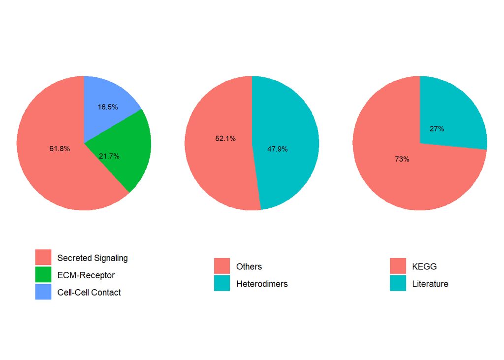

```r
CellChatDB <- CellChatDB.human # use CellChatDB.mouse if running on mouse data
showDatabaseCategory(CellChatDB)
```

```r
# CellChatDB.use <- subsetDB(CellChatDB, search = "Secreted Signaling") # use Secreted Signaling
CellChatDB.use <- CellChatDB # simply use the default CellChatDB

for (i in 1:5) {
  All.cellchat[[i]]@DB <- CellChatDB.use
}
```

```r
for (i in 1:5) {
  All.cellchat[[i]] <- subsetData(All.cellchat[[i]]) # This step is necessary even if using the whole database
  future::plan("multisession", workers = 4) # do parallel

  All.cellchat[[i]] <- identifyOverExpressedGenes(All.cellchat[[i]])
  All.cellchat[[i]] <- identifyOverExpressedInteractions(All.cellchat[[i]])
}
```

```r
for (i in 1:5) {
  All.cellchat[[i]] <- computeCommunProb(All.cellchat[[i]])
  # Filter out the cell-cell communication if there are only few number of cells in certain cell groups
  All.cellchat[[i]] <- filterCommunication(All.cellchat[[i]], min.cells = 10)
}
```

```r
for (i in 1:5) {
  All.cellchat[[i]] <- computeCommunProbPathway(All.cellchat[[i]])
  All.cellchat[[i]] <- aggregateNet(All.cellchat[[i]])
}
```

visualize cell-cell communications

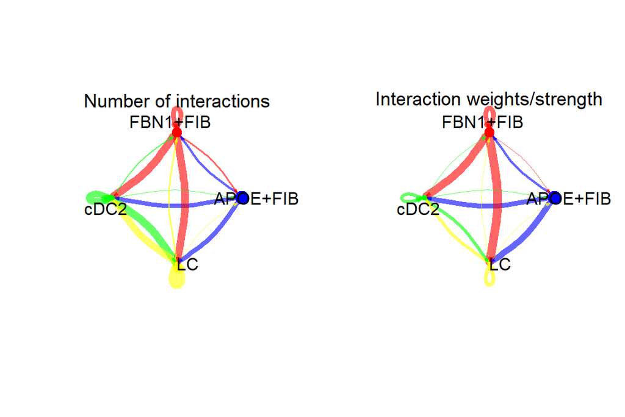

```r
i <- 5 #check the cell-cell communications between all four cell groups

groupSize <- as.numeric(table(All.cellchat[[i]]@idents))
par(mfrow = c(1,2), xpd=TRUE)

netVisual_circle(All.cellchat[[i]]@net$count, color.use = c("blue" , "red","green", "yellow"), vertex.weight = groupSize, weight.scale = T, label.edge= F, title.name = "Number of interactions")

netVisual_circle(All.cellchat[[i]]@net$weight, color.use = c("blue" , "red","green", "yellow"),vertex.weight = groupSize, weight.scale = T, label.edge= F, title.name = "Interaction weights/strength")
```

# Part IV: Infer the signaling network from APOE to FBN1+ FIB cells using exFINDER

From CellChat analysis we know that APOE (ligand) is only highly expressed in the APOE+ FIB cells and communicating to FBN1+ FIB cells. We then use exFINDER to infer the corresponding signaling network.

## Load exFINDER database

```r
# load exFINDER database
load("../data/LR_layer1_human.rda")
load("../data/RTF_layer2_human.rda")
load("../data/TFT_layer3_human.rda")

exFINDER.H <- list()
exFINDER.H[[1]] <- LR_layer1_human
exFINDER.H[[2]] <- RTF_layer2_human
exFINDER.H[[3]] <- TFT_layer3_human
```

```r
# setup input data
exp.data <- Data1@assays$RNA@data
meta.data <- Data1@meta.data
```

## exFINDER analysis

We choose the top10 marker genes of the FBN1+ FIB cells as targets.

```r
# setup input data
marker <- read.csv(file = "../markers/He2020_Human_marker/He2020_Human_markers_FBN1+FIB.csv")
target.gene <- marker$X[1:10]
```

The “get_ltGRN” infers ligand-target GRN based on prior knowledge (exFINDER-DB).

```r
# infer ltGRN
ltGRN <- get_ltGRN(Target = target.gene, DB = exFINDER.H)
```

calculate the percentile values of cell groups for determining the cutoff thresholds for “barely expressed genes” and “highly expressed genes” in later analysis

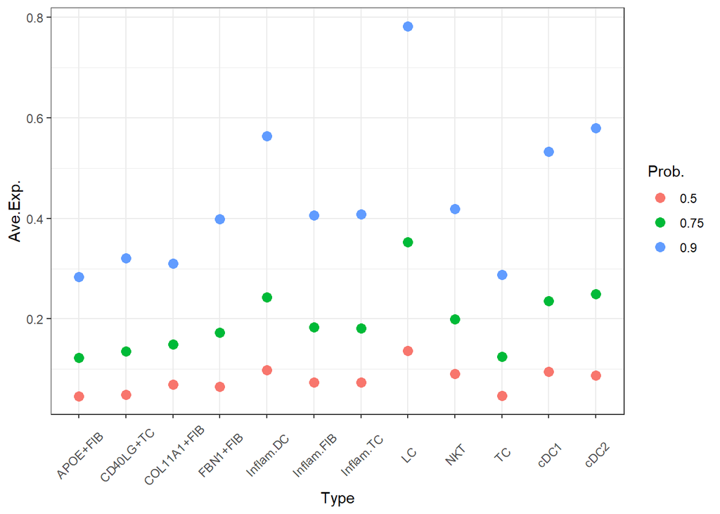

```r
data.input = exp.data[, barcode[[5]]]
meta.input = data.frame(Type = meta.data[barcode[[5]], ]$Type)
meta.input$Type <- fct_drop(meta.input$Type)
rownames(meta.input) <- barcode[[5]]

# Check the average expression levels in each cell population group
percentile_data <- get_percentile(Exp.Data = exp.data,
               Meta.Data = meta.data,
               percentile = c(.5, .75, .90))

p <- ggplot(data=percentile_data, aes(x=Type, y=Ave.Exp., color=Prob.)) +
  geom_point(size=3) +
  theme_bw() +
    theme(axis.text.x = element_text(angle = 45, hjust = 0.5, vjust = 0.5))

p
```

```r
# ggsave(p, filename="Benchmarking_percentile.pdf")
```

From the ltGRN, we can infer the corresponding receptors, TFs, and target genes highly expressed in the assigned cell groups, as well as the signaling network.

```r
# infer exSigNet (R, TF, T are all highly expressed, L comes from the potential external signals)
exSigNet <- get_exSigNet(Graph = ltGRN,
                       Ligands = "APOE",
                       Exp.Data = exp.data,
                       Meta.Data = meta.data,
                       par.cutoff = c(0.8, 0.8), # cutoff expression levels
                       AG.R = c('FBN1+FIB'), # select the receptors that highly expressed in the FBN1+ FIB cells
                       AG.TF = c('FBN1+FIB'))
```

```
#> [1] "No overlap found!"
```

```r
exSigNet
```

```
#> $Graph.Edge
#>     from     to   source        path from.Role  to.Role
#> 1   APOE   LRP1 NicheNet   APOE*LRP1    Ligand Receptor
#> 2   APOE   SDC2 NicheNet   APOE*SDC2    Ligand Receptor
#> 3   LRP1   CAV1 NicheNet   LRP1*CAV1  Receptor       TF
#> 4   SDC2  SPARC NicheNet  SDC2*SPARC  Receptor       TF
#> 5   SDC2   CAV1 NicheNet   SDC2*CAV1  Receptor       TF
#> 6   CAV1 CLEC3B NicheNet CAV1*CLEC3B        TF   Target
#> 7   CAV1  FSTL1 NicheNet  CAV1*FSTL1        TF   Target
#> 8  SPARC   PI16 NicheNet  SPARC*PI16        TF   Target
#> 9  SPARC  FSTL1 NicheNet SPARC*FSTL1        TF   Target
#> 10  CAV1 IGFBP6 NicheNet CAV1*IGFBP6        TF   Target
#>
#> $Graph.Node
#>     Gene     Role
#> 1   APOE   Ligand
#> 2   LRP1 Receptor
#> 3   SDC2 Receptor
#> 4   CAV1       TF
#> 5  SPARC       TF
#> 6 CLEC3B   Target
#> 7  FSTL1   Target
#> 8   PI16   Target
#> 9 IGFBP6   Target
```

Calculate expression levels of the genes(nodes), and predict signaling strength(weight).

```r
exSigNet <- get_NodeValue(Graph = exSigNet,
                          Exp.Data = exp.data,
                          Meta.Data = meta.data,
                          AG.R = c('FBN1+FIB'),
                          AG.TF = c('FBN1+FIB'),
                          AG.T = c('FBN1+FIB'),
                          Exp.ExData = NULL,
                          Meta.ExData = NULL,
                          AG.ExData = NULL)
exSigNet <- get_EdgeWeight(Graph = exSigNet,
               Kh = 2)
```

Then we can visualize their expression levels by plotting a heatmap.

```r
# prepare the dataframe for heatmap plot
exS_exp <- get_AveExp(Gene = exSigNet$Graph.Node$Gene,
           Exp.Data = exp.data,
           Meta.Data = meta.data)

exS_exp.HP <- exS_exp
exS_exp.HP <- exS_exp.HP[, -1]
row.names(exS_exp.HP) <- exS_exp$Gene

exS_exp.HP <- data.frame("APOE+ FIB" = exS_exp.HP$`APOE+FIB`,
                     "FBN1+ FIB" = exS_exp.HP$`FBN1+FIB`, 'cDC2' = exS_exp.HP$cDC2,
                     "LC" = exS_exp.HP$LC)
row.names(exS_exp.HP) <- exS_exp$Gene

# customize the row labels and col labels
annotation_row <- data.frame(Role = exSigNet$Graph.Node$Role)
row.names(annotation_row) <- row.names(exS_exp.HP)

head(exS_exp.HP)
```

```
#>        APOE..FIB FBN1..FIB       cDC2         LC
#> APOE   1.9267294 0.2023243 0.05552063 0.00000000
#> LRP1   1.7702188 2.2174485 0.10539589 0.02930784
#> SDC2   0.8316019 1.1269114 0.70825333 1.61134535
#> CAV1   1.0295428 1.0264577 0.03068774 0.00000000
#> SPARC  0.9506910 2.0833875 0.01944227 0.00000000
#> CLEC3B 1.3803502 2.5090399 0.04415369 0.05985847
```

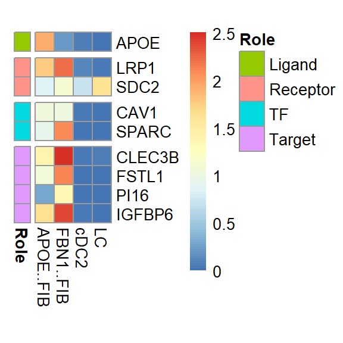

```r
# heatmap plot
pheatmap(exS_exp.HP,
        cluster_row = FALSE, cluster_cols = FALSE,
        cellwidth = 12, cellheight = 12,
        gaps_row = c(1, 3, 5),
        fontsize_row = 10,
        fontsize_col = 10,
        annotation_row = annotation_row)
```

Besides the above external signal (APOE) that highly expressed in the APOE+ FIB cells, we can also use exFINDER to check what ligands in the ltGRN are targeting FBN1+ FIB cells and their expression levels. Here we select the first 90 ligands in the ltGRN as an example and compare their expression levels with APOE.

```r
# select the first 90 ligands
ligand <- ltGRN$Graph.Node$Gene[ltGRN$Graph.Node$Role == "Ligand"][1:90]
ligand <- intersect(ligand, row.names(exp.data))

exSigNet <- get_exSigNet(Graph = ltGRN,
                       Ligands = c(ligand, "APOE"), # compare the expression levels with APOE
                       Exp.Data = exp.data,
                       Meta.Data = meta.data,
                       par.cutoff = c(0.8, 0.8),
                       AG.R = c('FBN1+FIB'),
                       AG.TF = c('FBN1+FIB'))

get_NetworkDetail(exSigNet) # show the details of exSigNet
```

```
#> Number of ligands:  25
#> Number of receptors:  9
#> Number of tfs:  6
#> Number of targets:  7
#> Number of L-R pairs:  34
#> Number of R-TF pairs:  18
#> Number of TF-T pairs:  15
```

[figure not shown]

```r
# check the inferred external signals and their expressions
exS <- exSigNet$Graph.Node$Gene[exSigNet$Graph.Node$Role == "Ligand"]

get_heatmap(Gene = exS,
            Exp.Data = exp.data,
            Meta.Data = meta.data,
            cellwidth = 15,
            cellheight = 15,
            gaps_col = NULL,
            gaps_row = NULL,
            fontsize_row = 10,
            fontsize_col = 10,
            angle_col = 0,)
```

# Part V: Compare the results provided from CellChat and exFINDER

By comparing the CellChat analysis results of five datasets (four contain three cell groups, and one contains four cell groups), we can obtain the following information:

(1). the ligands coming from any of the four cell groups talk to one cell group; (2). the ligands coming from a specific cell groups talk to one cell group.

```r
cell_type <- c("LC", "cDC2", "FBN1+FIB", "APOE+FIB")

CC_ligand <- list()

for (k in 1:4) {

  network5 <- subsetCommunication(All.cellchat[[5]], targets.use = cell_type[k])
  CC_L5 <- unique(network5$ligand) # all ligands targeting cell_type[k]
  CC_ligand[[5 + 5*(k-1)]] <- CC_L5

  for (i in 1:4) {
      # ligands from dataset i targeting cell_type[k]
      network <- subsetCommunication(All.cellchat[[i]], targets.use = cell_type[k])
      # ligands from the cells not included in dataset i targeting cell_type[k]
      CC_L <- setdiff(CC_L5,  unique(network$ligand))
      CC_ligand[[i + 5*(k-1)]] <- CC_L

  }

  CC_ligand[[k + 5*(k-1)]] <-setdiff( unique(c(CC_ligand[[1+ 5*(k-1)]], CC_ligand[[2+ 5*(k-1)]], CC_ligand[[3+ 5*(k-1)]], CC_ligand[[4+ 5*(k-1)]])), CC_ligand[[5+ 5*(k-1)]]) # ligands from cell_type[k] targeting itself

}
```

Firstly, for each cell group, we employ exFINDER to infer the ligand-target GRN targeting its top 10 marker genes, to obtain the corresponding ligands.

Secondly, we remove each cell group from the data (one at a time) such that they become the “external cells” for the rest cells in the data. So the inputs will only contain the remaining three cell groups. And now CellChat is unable to infer the ligands produced by the “external cells” (since they are not in the inputs). Then we use exFINDER to identify the ligands come from the “external cells” (also can be regaded as “external siganls”).

```r
exF_ligand <- list()
barcode <- mget(paste0('cell.use', 1:5))

for (k in 1:4) {
  # top 10 marker genes of cell_type[k]
  marker <- read.csv(file = paste("../markers/He2020_Human_marker/He2020_Human_markers_",cell_type[k],".csv",sep=""))
  marker_list <- marker$X[1:10]

  ltGRN <- get_ltGRN(Target = marker_list, DB = exFINDER.H)
  # infer all ligands that highly expressed in at least one cell group
  exS_0 <- get_potentialex(Graph = ltGRN,
                Exp.Data = exp.data,
                Meta.Data = meta.data,
                cutoff = 0,
                AG.L = c("LC", "cDC2", "FBN1+FIB", "APOE+FIB")) # ligands can come from any of the four cell groups
  exF_ligand[[5 + 5*(k-1)]] <- exS_0

  for (i in 1:4) {
    # select cells of dataset i
    data.input = exp.data[, barcode[[i]]]
    meta.input = data.frame(Type = meta.data[barcode[[i]], ]$Type)
    meta.input$Type <- fct_drop(meta.input$Type)
    rownames(meta.input) <- barcode[[i]]

    # infer ligands that not highly expressed in dataset i
    # (so they may be highly expressed by the cells outside dataset i)
    exS_1 <- get_potentialex(Graph = ltGRN,
                Exp.Data = data.input,
                Meta.Data = meta.input,
                cutoff = -0.8,
                AG.L = NULL)

    exF_ligand[[i + 5*(k-1)]] <- exS_1
  }

}
```

By comparing the results, we can calculate the recovery rate – the proportion of the CellChat-inferred ligands that captured by exFINDER.

```r
coverR <- c()

for (j in 1:length(exF_ligand)) {
  # if CellChat does not find such ligands, then we set "cover rate"=NULL
  if ( length(CC_ligand[[j]])==0 ){
    coverR[j] <- "NULL"
  } else{
    coverR[j] <- 1- length(setdiff(CC_ligand[[j]], exF_ligand[[j]]))/length(CC_ligand[[j]])
  }
}

coverR[coverR == "NULL"] <- NaN
coverR <- as.numeric(coverR)

df <- data.frame("LC" = coverR[1:5], "cDC2" = coverR[6:10],
                  "FBN1+ FIB" = coverR[11:15], "APOE+ FIB" = coverR[16:20])
rownames(df) <- c("LC-specific", "cDC2-specific", "FBN1+ FIB-specific", "APOE+ FIB-specific", "All cell groups")
df
```

```
#>                           LC    cDC2 FBN1..FIB APOE..FIB
#> LC-specific              NaN 1.00000      1.00       1.0
#> cDC2-specific      0.4000000     NaN      0.75       0.5
#> FBN1+ FIB-specific 0.8750000 1.00000       NaN       1.0
#> APOE+ FIB-specific 1.0000000     NaN       NaN       NaN
#> All cell groups    0.9722222 0.96875      1.00       1.0
```

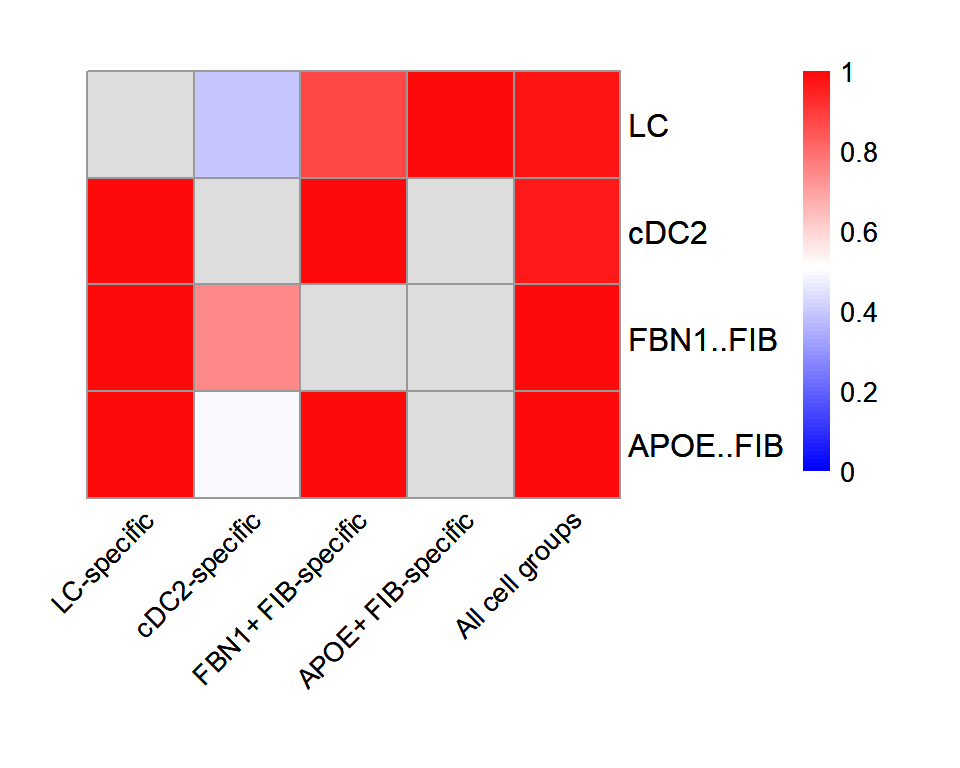

```r
bk <- c(seq(0,0.59,by=0.01), seq(0.6,1,by=0.01))

p <- pheatmap(t(df),
         cluster_row = FALSE, cluster_cols = FALSE,
         cellwidth = 40, cellheight = 40,
         fontsize_row = 12,
         fontsize_col = 10,
         angle_col = 45,
         color = c(colorRampPalette(colors = c("blue","white"))(length(bk)/2),colorRampPalette(colors = c("white","red"))(length(bk)/2)),
         breaks=bk)
p
```

```r
# ggsave(p, filename="Heatmap_Human_CC_exFINDER.pdf")
```